# NCBI vs Ensembl Annotation Comparison for Ssal_v3.1

Generated by Claude Code

2026-02-03

# Overview

This report compares NCBI and Ensembl gene annotations for the Atlantic salmon Ssal_v3.1 assembly. The comparison uses a custom within-assembly comparison script that computes overlap metrics at both gene and transcript levels.

**Data:** - Annotation A: NCBI (GCF_905237065.1_Ssal_v3.1) - Annotation B: Ensembl (Ssal_v3.1) - Comparison date: 2026-02-03

# Load Libraries and Data

```r
library(tidyverse)
library(scales)
library(patchwork)

# Custom theme
theme_set(theme_minimal(base_size = 12))
```

```r
# Read comparison data
comparison <- read_tsv("comparison.tsv", show_col_types = FALSE)

# Separate gene-level and transcript-level data
genes <- comparison %>%
  filter(feature == "gene")

transcripts <- comparison %>%
  filter(feature == "transcript")

# Parse gene-level stats
genes_parsed <- genes %>%
  mutate(
    # Extract key metrics from stats column
    class = str_extract(stats, "class=([^;]+)") %>% str_remove("class="),
    class_initial = str_extract(stats, "class_initial=([^;]+)") %>% str_remove("class_initial="),
    best_coding = str_extract(stats, "best_coding=([^;]+)") %>% str_remove("best_coding="),
    best_noncoding = str_extract(stats, "best_noncoding=([^;]+)") %>% str_remove("best_noncoding="),
    best_jaccard_exon = str_extract(stats, "best_jaccard_exon=([0-9.]+)") %>%
      str_remove("best_jaccard_exon=") %>% as.numeric(),
    best_jaccard_cds = str_extract(stats, "best_jaccard_cds_phase=([0-9.]+)") %>%
      str_remove("best_jaccard_cds_phase=") %>% as.numeric(),
    partner_countA = str_extract(stats, "partner_countA=([0-9]+)") %>%
      str_remove("partner_countA=") %>% as.integer(),
    partner_countB = str_extract(stats, "partner_countB=([0-9]+)") %>%
      str_remove("partner_countB=") %>% as.integer(),
    overlap_bp = str_extract(stats, "overlap_bp=([0-9]+)") %>%
      str_remove("overlap_bp=") %>% as.integer(),
    split_mergeA = str_detect(stats, "note_split_or_merge_A"),
    split_mergeB = str_detect(stats, "note_split_or_merge_B")
  )

# Parse transcript-level stats
transcripts_parsed <- transcripts %>%
  mutate(
    # Extract key metrics
    class = str_extract(stats, "class=([^;]+)") %>% str_remove("class="),
    jaccard_exon = str_extract(stats, "jaccard_exon=([0-9.]+)") %>%
      str_remove("jaccard_exon=") %>% as.numeric(),
    jaccard_cds = str_extract(stats, "jaccard_cds_phase=([0-9.]+)") %>%
      str_remove("jaccard_cds_phase=") %>% as.numeric(),
    junction_f1_all = str_extract(stats, "junction_f1_all=([0-9.]+)") %>%
      str_remove("junction_f1_all=") %>% as.numeric(),
    junction_f1_cds = str_extract(stats, "junction_f1_cds=([0-9.]+)") %>%
      str_remove("junction_f1_cds=") %>% as.numeric(),
    strand_agree = str_extract(stats, "strand_agree=([01])") %>%
      str_remove("strand_agree=") %>% as.integer(),
    monoexonicA = str_extract(stats, "monoexonicA=([01])") %>%
      str_remove("monoexonicA=") %>% as.integer(),
    monoexonicB = str_extract(stats, "monoexonicB=([01])") %>%
      str_remove("monoexonicB=") %>% as.integer(),
    bpA = str_extract(stats, "bpA=([0-9]+)") %>% str_remove("bpA=") %>% as.integer(),
    bpB = str_extract(stats, "bpB=([0-9]+)") %>% str_remove("bpB=") %>% as.integer(),
    cds_bpA = str_extract(stats, "cds_bpA=([0-9]+)") %>% str_remove("cds_bpA=") %>% as.integer(),
    cds_bpB = str_extract(stats, "cds_bpB=([0-9]+)") %>% str_remove("cds_bpB=") %>% as.integer(),
    # Determine transcript type
    is_coding_A = cds_bpA > 0,
    is_coding_B = cds_bpB > 0,
    coding_status = case_when(
      is_coding_A & is_coding_B ~ "Both coding",
      !is_coding_A & !is_coding_B ~ "Both non-coding",
      is_coding_A & !is_coding_B ~ "NCBI coding, Ensembl non-coding",
      !is_coding_A & is_coding_B ~ "NCBI non-coding, Ensembl coding"
    ),
    is_monoexonic = monoexonicA == 1 | monoexonicB == 1
  )
```

# Summary Statistics

```r
cat("Total genes in NCBI annotation:", length(unique(genes$geneA)), "\n")
```

```
## Total genes in NCBI annotation: 42041
```

```r
cat("Total genes in Ensembl annotation:", length(unique(genes$geneB)), "\n")
```

```
## Total genes in Ensembl annotation: 40589
```

```r
cat("Gene pairs compared:", nrow(genes), "\n")
```

```
## Gene pairs compared: 52514
```

```r
cat("\nTotal transcripts compared:", nrow(transcripts), "\n")
```

```
##
## Total transcripts compared: 476167
```

# Gene-Level Classification

## Classification Distribution

```r
# Count by classification
class_counts <- genes_parsed %>%
  count(class) %>%
  mutate(
    percent = n / sum(n) * 100,
    class = factor(class, levels = c("Green", "Yellow", "Red", "NotMapped"))
  ) %>%
  arrange(class)

# Display table
class_counts %>%
  knitr::kable(
    caption = "Gene-level classification distribution",
    col.names = c("Classification", "Count", "Percent"),
    digits = 2
  )
```

Gene-level classification distribution

| Classification | Count | Percent |
| --- | --- | --- |
| Green | 16426 | 31.28 |
| Yellow | 19938 | 37.97 |
| Red | 3988 | 7.59 |
| NotMapped | 12162 | 23.16 |

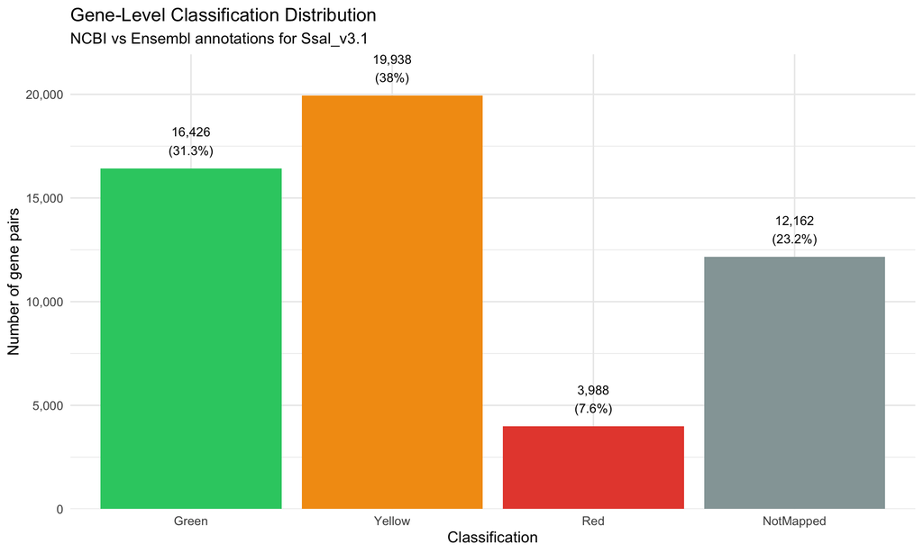

```r
# Plot
ggplot(class_counts, aes(x = class, y = n, fill = class)) +
  geom_col() +
  geom_text(aes(label = paste0(comma(n), "\n(", round(percent, 1), "%)")),
            vjust = -0.5, size = 3.5) +
  scale_fill_manual(
    values = c("Green" = "#2ecc71", "Yellow" = "#f39c12",
               "Red" = "#e74c3c", "NotMapped" = "#95a5a6")
  ) +
  scale_y_continuous(labels = comma, expand = expansion(mult = c(0, 0.1))) +
  labs(
    title = "Gene-Level Classification Distribution",
    subtitle = "NCBI vs Ensembl annotations for Ssal_v3.1",
    x = "Classification",
    y = "Number of gene pairs",
    fill = "Class"
  ) +
  theme(legend.position = "none")
```

## Overlap Quality Metrics

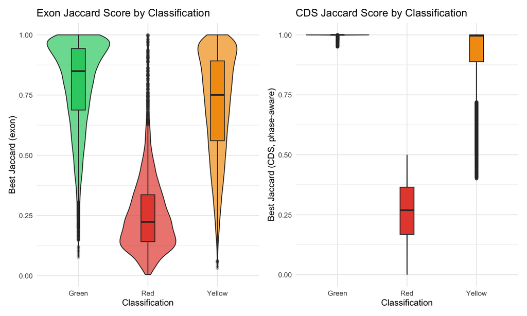

```r
# Filter for genes with overlaps
genes_with_overlap <- genes_parsed %>%
  filter(class != "NotMapped")

p1 <- ggplot(genes_with_overlap, aes(x = class, y = best_jaccard_exon, fill = class)) +
  geom_violin(alpha = 0.7) +
  geom_boxplot(width = 0.2, outlier.alpha = 0.3) +
  scale_fill_manual(
    values = c("Green" = "#2ecc71", "Yellow" = "#f39c12", "Red" = "#e74c3c")
  ) +
  labs(
    title = "Exon Jaccard Score by Classification",
    x = "Classification",
    y = "Best Jaccard (exon)"
  ) +
  theme(legend.position = "none")

p2 <- ggplot(genes_with_overlap %>% filter(best_jaccard_cds > 0),
             aes(x = class, y = best_jaccard_cds, fill = class)) +
  geom_violin(alpha = 0.7) +
  geom_boxplot(width = 0.2, outlier.alpha = 0.3) +
  scale_fill_manual(
    values = c("Green" = "#2ecc71", "Yellow" = "#f39c12", "Red" = "#e74c3c")
  ) +
  labs(
    title = "CDS Jaccard Score by Classification",
    x = "Classification",
    y = "Best Jaccard (CDS, phase-aware)"
  ) +
  theme(legend.position = "none")

p1 + p2
```

## Split/Merge Analysis

```r
# Count genes with multiple partners
split_merge_stats <- genes_parsed %>%
  summarise(
    split_A = sum(partner_countA > 1, na.rm = TRUE),
    split_B = sum(partner_countB > 1, na.rm = TRUE),
    merge_both = sum(partner_countA > 1 & partner_countB > 1, na.rm = TRUE)
  )

cat("Genes with multiple partners:\n")
```

```
## Genes with multiple partners:
```

```r
cat("  NCBI genes mapping to multiple Ensembl genes:", split_merge_stats$split_A, "\n")
```

```
##   NCBI genes mapping to multiple Ensembl genes: 19769
```

```r
cat("  Ensembl genes mapping to multiple NCBI genes:", split_merge_stats$split_B, "\n")
```

```
##   Ensembl genes mapping to multiple NCBI genes: 21686
```

```r
cat("  Complex cases (both have multiple partners):", split_merge_stats$merge_both, "\n")
```

```
##   Complex cases (both have multiple partners): 12607
```

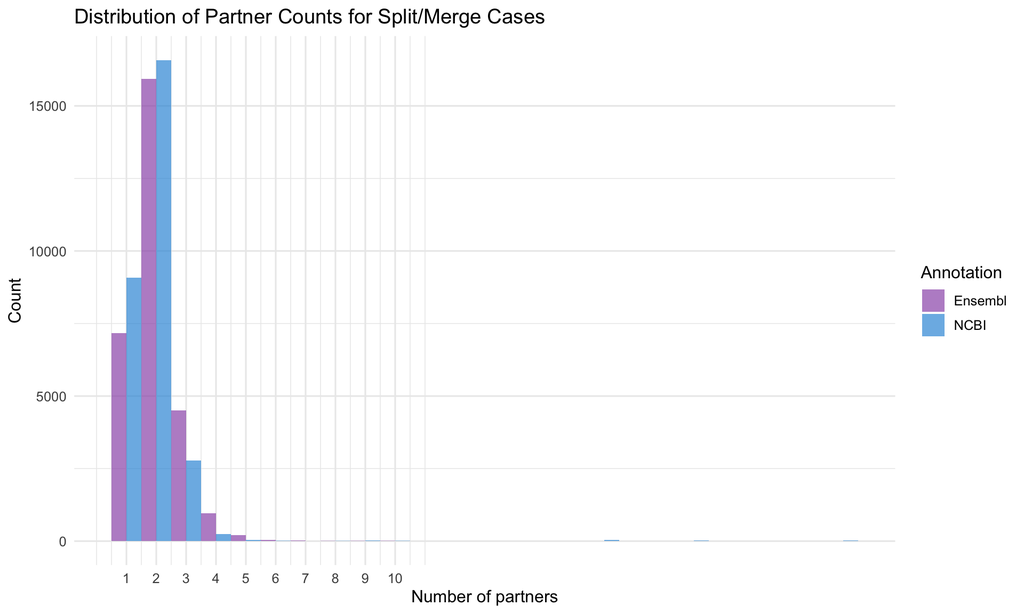

```r
# Partner count distribution
partner_dist <- genes_parsed %>%
  filter(partner_countA > 1 | partner_countB > 1) %>%
  select(geneA, geneB, partner_countA, partner_countB, class) %>%
  pivot_longer(
    cols = c(partner_countA, partner_countB),
    names_to = "annotation",
    values_to = "partner_count"
  ) %>%
  mutate(annotation = if_else(annotation == "partner_countA", "NCBI", "Ensembl"))

ggplot(partner_dist, aes(x = partner_count, fill = annotation)) +
  geom_histogram(binwidth = 1, position = "dodge", alpha = 0.7) +
  scale_x_continuous(breaks = 1:10) +
  scale_fill_manual(values = c("NCBI" = "#3498db", "Ensembl" = "#9b59b6")) +
  labs(
    title = "Distribution of Partner Counts for Split/Merge Cases",
    x = "Number of partners",
    y = "Count",
    fill = "Annotation"
  )
```

# Transcript-Level Analysis

## Coding Status Agreement

```r
# Summary of coding status agreement
coding_summary <- transcripts_parsed %>%
  count(coding_status) %>%
  mutate(
    percent = n / sum(n) * 100,
    coding_status = factor(coding_status, levels = c(
      "Both coding", "Both non-coding",
      "NCBI coding, Ensembl non-coding", "NCBI non-coding, Ensembl coding"
    ))
  )

coding_summary %>%
  knitr::kable(
    caption = "Coding status agreement between annotations",
    col.names = c("Coding Status", "Count", "Percent"),
    digits = 2
  )
```

Coding status agreement between annotations

| Coding Status | Count | Percent |
| --- | --- | --- |
| Both coding | 452094 | 94.94 |
| NCBI non-coding, Ensembl coding | 24073 | 5.06 |

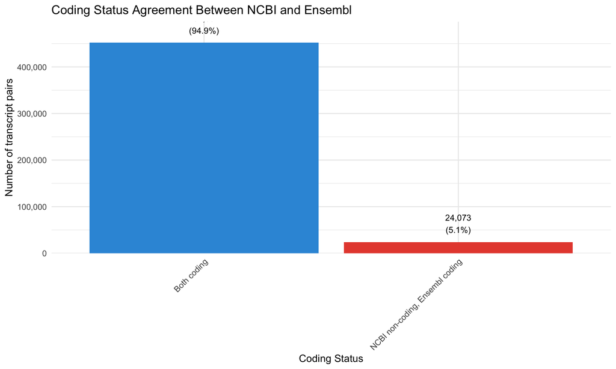

```r
# Visualize
ggplot(coding_summary, aes(x = coding_status, y = n, fill = coding_status)) +
  geom_col() +
  geom_text(aes(label = paste0(comma(n), "\n(", round(percent, 1), "%)")),
            vjust = -0.5, size = 3.5) +
  scale_fill_manual(
    values = c(
      "Both coding" = "#3498db",
      "Both non-coding" = "#9b59b6",
      "NCBI coding, Ensembl non-coding" = "#e67e22",
      "NCBI non-coding, Ensembl coding" = "#e74c3c"
    )
  ) +
  scale_y_continuous(labels = comma, expand = expansion(mult = c(0, 0.1))) +
  labs(
    title = "Coding Status Agreement Between NCBI and Ensembl",
    x = "Coding Status",
    y = "Number of transcript pairs",
    fill = "Status"
  ) +
  theme(
    axis.text.x = element_text(angle = 45, hjust = 1),
    legend.position = "none"
  )
```

## Classification by Transcript Type

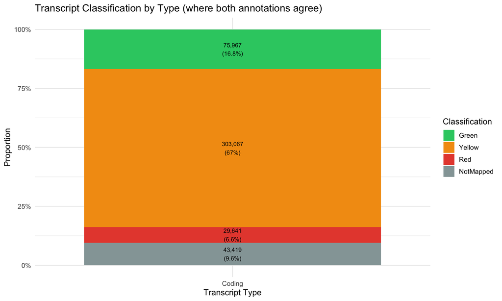

```r
# Classification by coding status (only where both agree)
tx_class_summary <- transcripts_parsed %>%
  filter(coding_status %in% c("Both coding", "Both non-coding")) %>%
  mutate(type = if_else(coding_status == "Both coding", "Coding", "Non-coding")) %>%
  group_by(type, class) %>%
  summarise(count = n(), .groups = "drop") %>%
  group_by(type) %>%
  mutate(
    percent = count / sum(count) * 100,
    class = factor(class, levels = c("Green", "Yellow", "Red", "NotMapped"))
  ) %>%
  ungroup()

ggplot(tx_class_summary, aes(x = type, y = count, fill = class)) +
  geom_col(position = "fill") +
  geom_text(
    aes(label = paste0(comma(count), "\n(", round(percent, 1), "%)")),
    position = position_fill(vjust = 0.5),
    size = 3
  ) +
  scale_fill_manual(
    values = c("Green" = "#2ecc71", "Yellow" = "#f39c12",
               "Red" = "#e74c3c", "NotMapped" = "#95a5a6")
  ) +
  scale_y_continuous(labels = percent) +
  labs(
    title = "Transcript Classification by Type (where both annotations agree)",
    x = "Transcript Type",
    y = "Proportion",
    fill = "Classification"
  )
```

## Metric Distributions for High-Quality Matches

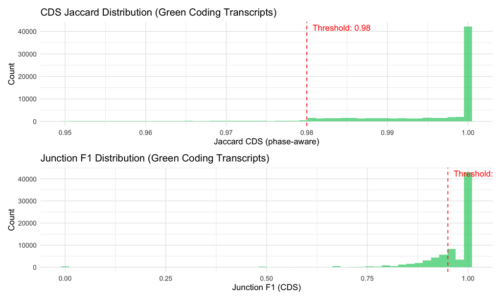

```r
# Filter for Green class transcripts
green_tx <- transcripts_parsed %>%
  filter(class == "Green")

# Create metrics plots (only for transcripts both annotations agree are coding)
p1 <- ggplot(green_tx %>% filter(coding_status == "Both coding"),
             aes(x = jaccard_cds)) +
  geom_histogram(bins = 50, fill = "#2ecc71", alpha = 0.7) +
  geom_vline(xintercept = 0.98, linetype = "dashed", color = "red") +
  labs(
    title = "CDS Jaccard Distribution (Green Coding Transcripts)",
    x = "Jaccard CDS (phase-aware)",
    y = "Count"
  ) +
  annotate("text", x = 0.98, y = Inf, label = "Threshold: 0.98",
           vjust = 1.5, hjust = -0.1, color = "red")

p2 <- ggplot(green_tx %>% filter(coding_status == "Both coding"),
             aes(x = junction_f1_cds)) +
  geom_histogram(bins = 50, fill = "#2ecc71", alpha = 0.7) +
  geom_vline(xintercept = 0.95, linetype = "dashed", color = "red") +
  labs(
    title = "Junction F1 Distribution (Green Coding Transcripts)",
    x = "Junction F1 (CDS)",
    y = "Count"
  ) +
  annotate("text", x = 0.95, y = Inf, label = "Threshold: 0.95",
           vjust = 1.5, hjust = -0.1, color = "red")

p1 / p2
```

## Strand Agreement

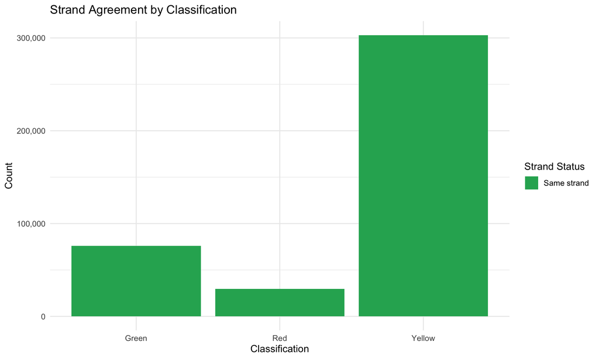

```r
strand_summary <- transcripts_parsed %>%
  filter(class != "NotMapped") %>%
  mutate(strand_status = if_else(strand_agree == 1, "Same strand", "Antisense")) %>%
  group_by(strand_status, class) %>%
  summarise(count = n(), .groups = "drop")

ggplot(strand_summary, aes(x = class, y = count, fill = strand_status)) +
  geom_col(position = "dodge") +
  scale_fill_manual(values = c("Same strand" = "#27ae60", "Antisense" = "#c0392b")) +
  scale_y_continuous(labels = comma) +
  labs(
    title = "Strand Agreement by Classification",
    x = "Classification",
    y = "Count",
    fill = "Strand Status"
  )
```

## Monoexonic vs Multiexonic Transcripts

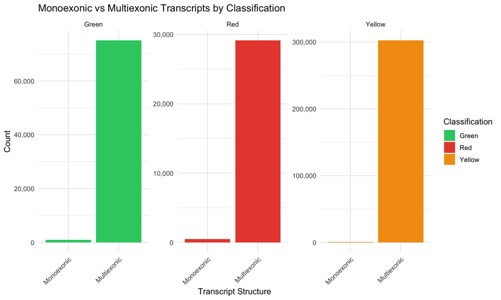

```r
mono_summary <- transcripts_parsed %>%
  filter(class != "NotMapped") %>%
  mutate(
    exon_status = case_when(
      is_monoexonic ~ "Monoexonic",
      TRUE ~ "Multiexonic"
    )
  ) %>%
  group_by(exon_status, class) %>%
  summarise(count = n(), .groups = "drop")

ggplot(mono_summary, aes(x = exon_status, y = count, fill = class)) +
  geom_col() +
  scale_fill_manual(
    values = c("Green" = "#2ecc71", "Yellow" = "#f39c12",
               "Red" = "#e74c3c", "NotMapped" = "#95a5a6")
  ) +
  scale_y_continuous(labels = comma) +
  facet_wrap(~class, scales = "free_y") +
  labs(
    title = "Monoexonic vs Multiexonic Transcripts by Classification",
    x = "Transcript Structure",
    y = "Count",
    fill = "Classification"
  ) +
  theme(axis.text.x = element_text(angle = 45, hjust = 1))
```

# Detailed Statistics

## Gene-Level Summary

```r
genes_parsed %>%
  group_by(class) %>%
  summarise(
    count = n(),
    median_jaccard_exon = median(best_jaccard_exon, na.rm = TRUE),
    median_jaccard_cds = median(best_jaccard_cds[best_jaccard_cds > 0], na.rm = TRUE),
    mean_partners_A = mean(partner_countA, na.rm = TRUE),
    mean_partners_B = mean(partner_countB, na.rm = TRUE),
    split_merge_cases = sum(split_mergeA | split_mergeB, na.rm = TRUE)
  ) %>%
  knitr::kable(
    caption = "Gene-level summary by classification",
    digits = 3,
    col.names = c("Class", "Count", "Median Jaccard Exon", "Median Jaccard CDS",
                  "Mean Partners (NCBI)", "Mean Partners (Ensembl)", "Split/Merge Cases")
  )
```

Gene-level summary by classification

| Class | Count | Median Jaccard Exon | Median Jaccard CDS | Mean Partners (NCBI) | Mean Partners (Ensembl) | Split/Merge Cases |
| --- | --- | --- | --- | --- | --- | --- |
| Green | 16426 | 0.850 | 1.000 | 1.000 | 1.000 | 0 |
| NotMapped | 12162 | 0.057 | 0.056 | 2.075 | 2.141 | 11551 |
| Red | 3988 | 0.224 | 0.269 | 1.609 | 1.906 | 3246 |
| Yellow | 19938 | 0.751 | 0.997 | 1.471 | 1.586 | 14051 |

## Transcript-Level Summary

```r
transcripts_parsed %>%
  filter(class != "NotMapped") %>%
  group_by(class, coding_status) %>%
  summarise(
    count = n(),
    median_jaccard_exon = median(jaccard_exon, na.rm = TRUE),
    median_jaccard_cds = median(jaccard_cds[jaccard_cds > 0], na.rm = TRUE),
    median_junction_f1_all = median(junction_f1_all, na.rm = TRUE),
    median_junction_f1_cds = median(junction_f1_cds[junction_f1_cds > 0], na.rm = TRUE),
    .groups = "drop"
  ) %>%
  knitr::kable(
    caption = "Transcript-level summary by classification and coding status",
    digits = 3,
    col.names = c("Class", "Coding Status", "Count", "Median J.Exon", "Median J.CDS",
                  "Median F1 All", "Median F1 CDS")
  )
```

Transcript-level summary by classification and coding status

| Class | Coding Status | Count | Median J.Exon | Median J.CDS | Median F1 All | Median F1 CDS |
| --- | --- | --- | --- | --- | --- | --- |
| Green | Both coding | 75967 | 0.774 | 1.000 | 0.923 | 1.000 |
| Red | Both coding | 29641 | 0.241 | 0.277 | 0.339 | 0.400 |
| Yellow | Both coding | 303067 | 0.636 | 0.858 | 0.759 | 0.783 |

# Examples

## High-Quality Matches (Green)

```r
green_examples <- genes_parsed %>%
  filter(class == "Green") %>%
  arrange(desc(best_jaccard_cds)) %>%
  select(geneA, geneB, best_jaccard_exon, best_jaccard_cds,
         partner_countA, partner_countB) %>%
  head(10)

green_examples %>%
  knitr::kable(
    caption = "Top 10 high-quality gene matches (Green classification)",
    digits = 4,
    col.names = c("NCBI Gene", "Ensembl Gene", "Jaccard Exon", "Jaccard CDS",
                  "NCBI Partners", "Ensembl Partners")
  )
```

Top 10 high-quality gene matches (Green classification)

| NCBI Gene | Ensembl Gene | Jaccard Exon | Jaccard CDS | NCBI Partners | Ensembl Partners |
| --- | --- | --- | --- | --- | --- |
| gene-wdr32 | gene:ENSSSAG00000000063 | 0.9395 | 1 | 1 | 1 |
| gene-manba | gene:ENSSSAG00000000049 | 0.9099 | 1 | 1 | 1 |
| gene-LOC106607815 | gene:ENSSSAG00000101513 | 0.9227 | 1 | 1 | 1 |
| gene-LOC106606645 | gene:ENSSSAG00000000051 | 0.9543 | 1 | 1 | 1 |
| gene-neff2 | gene:ENSSSAG00000000052 | 0.6836 | 1 | 1 | 1 |
| gene-LOC106593885 | gene:ENSSSAG00000098245 | 0.9053 | 1 | 1 | 1 |
| gene-LOC100316613 | gene:ENSSSAG00000000057 | 0.8527 | 1 | 1 | 1 |
| gene-noto | gene:ENSSSAG00000000055 | 0.7084 | 1 | 1 | 1 |
| gene-LOC106593289 | gene:ENSSSAG00000088197 | 0.4431 | 1 | 1 | 1 |
| gene-gfra4a | gene:ENSSSAG00000105454 | 0.8786 | 1 | 1 | 1 |

## Problematic Cases (Red)

```r
red_examples <- genes_parsed %>%
  filter(class == "Red") %>%
  arrange(desc(overlap_bp)) %>%
  select(geneA, geneB, best_jaccard_exon, overlap_bp,
         partner_countA, partner_countB) %>%
  head(10)

red_examples %>%
  knitr::kable(
    caption = "Top 10 weak matches by overlap (Red classification)",
    digits = 4,
    col.names = c("NCBI Gene", "Ensembl Gene", "Jaccard Exon", "Overlap BP",
                  "NCBI Partners", "Ensembl Partners")
  )
```

Top 10 weak matches by overlap (Red classification)

| NCBI Gene | Ensembl Gene | Jaccard Exon | Overlap BP | NCBI Partners | Ensembl Partners |
| --- | --- | --- | --- | --- | --- |
| gene-LOC106572669 | gene:ENSSSAG00000066962 | 0.8190 | 16038 | 1 | 1 |
| gene-dchs2 | gene:ENSSSAG00000004954 | 0.8358 | 11167 | 1 | 1 |
| gene-LOC106613969 | gene:ENSSSAG00000054732 | 0.6110 | 11086 | 1 | 2 |
| gene-LOC106610951 | gene:ENSSSAG00000100817 | 0.7250 | 10788 | 1 | 1 |
| gene-LOC106574049 | gene:ENSSSAG00000043025 | 0.5935 | 10603 | 1 | 3 |
| gene-LOC106572434 | gene:ENSSSAG00000068717 | 0.6889 | 9878 | 1 | 2 |
| gene-LOC106569344 | gene:ENSSSAG00000049398 | 0.4880 | 9870 | 2 | 1 |
| gene-LOC106601207 | gene:ENSSSAG00000099900 | 0.8297 | 9734 | 2 | 1 |
| gene-macf1b | gene:ENSSSAG00000032530 | 0.9565 | 9676 | 2 | 1 |
| gene-LOC106572557 | gene:ENSSSAG00000070266 | 0.9693 | 9419 | 1 | 1 |

## Split/Merge Cases

```r
split_merge_examples <- genes_parsed %>%
  filter(partner_countA > 1 | partner_countB > 1) %>%
  arrange(desc(partner_countA + partner_countB)) %>%
  select(geneA, geneB, class, partner_countA, partner_countB,
         best_jaccard_exon, best_jaccard_cds) %>%
  head(15)

split_merge_examples %>%
  knitr::kable(
    caption = "Examples of split/merge cases",
    digits = 4,
    col.names = c("NCBI Gene", "Ensembl Gene", "Class",
                  "NCBI Partners", "Ensembl Partners",
                  "Jaccard Exon", "Jaccard CDS")
  )
```

Examples of split/merge cases

| NCBI Gene | Ensembl Gene | Class | NCBI Partners | Ensembl Partners | Jaccard Exon | Jaccard CDS |
| --- | --- | --- | --- | --- | --- | --- |
| gene-LOC106569673 | gene:ENSSSAG00000106026 | NotMapped | 25 | 2 | 0.0145 | 0.0130 |
| gene-LOC106569673 | gene:ENSSSAG00000067719 | Yellow | 25 | 1 | 0.4561 | 0.4609 |
| gene-LOC106569673 | gene:ENSSSAG00000103783 | NotMapped | 25 | 1 | 0.0153 | 0.0162 |
| gene-LOC106569673 | gene:ENSSSAG00000014607 | NotMapped | 25 | 1 | 0.0153 | 0.0162 |
| gene-LOC106569673 | gene:ENSSSAG00000111464 | NotMapped | 25 | 1 | 0.0153 | 0.0162 |
| gene-LOC106569673 | gene:ENSSSAG00000088150 | NotMapped | 25 | 1 | 0.0153 | 0.0162 |
| gene-LOC106569673 | gene:ENSSSAG00000119842 | NotMapped | 25 | 1 | 0.0153 | 0.0162 |
| gene-LOC106569673 | gene:ENSSSAG00000113623 | NotMapped | 25 | 1 | 0.0153 | 0.0162 |
| gene-LOC106569673 | gene:ENSSSAG00000111681 | NotMapped | 25 | 1 | 0.0152 | 0.0162 |
| gene-LOC106569673 | gene:ENSSSAG00000103584 | NotMapped | 25 | 1 | 0.0153 | 0.0162 |
| gene-LOC106569673 | gene:ENSSSAG00000089787 | NotMapped | 25 | 1 | 0.0152 | 0.0162 |
| gene-LOC106569673 | gene:ENSSSAG00000087852 | NotMapped | 25 | 1 | 0.0153 | 0.0162 |
| gene-LOC106569673 | gene:ENSSSAG00000120234 | NotMapped | 25 | 1 | 0.0153 | 0.0162 |
| gene-LOC106569673 | gene:ENSSSAG00000090899 | NotMapped | 25 | 1 | 0.0153 | 0.0162 |
| gene-LOC106569673 | gene:ENSSSAG00000110344 | NotMapped | 25 | 1 | 0.0153 | 0.0162 |

# Conclusions

## Key Findings

```r
total_genes <- nrow(genes)
green_pct <- sum(genes_parsed$class == "Green") / total_genes * 100
yellow_pct <- sum(genes_parsed$class == "Yellow") / total_genes * 100
red_pct <- sum(genes_parsed$class == "Red") / total_genes * 100
not_mapped_pct <- sum(genes_parsed$class == "NotMapped") / total_genes * 100

both_coding_green_pct <- transcripts_parsed %>%
  filter(coding_status == "Both coding") %>%
  summarise(pct = sum(class == "Green") / n() * 100) %>%
  pull(pct)

coding_disagreement_pct <- transcripts_parsed %>%
  filter(coding_status %in% c("NCBI coding, Ensembl non-coding", "NCBI non-coding, Ensembl coding")) %>%
  nrow() / nrow(transcripts_parsed) * 100
```

- **High-quality matches (Green):** 31.3% of gene pairs show strong agreement between NCBI and Ensembl annotations
- **Significant differences (Yellow):** 38% of gene pairs have notable structural differences
- **Weak evidence (Red):** 7.6% of gene pairs have minimal overlap or antisense orientation
- **Not mapped:** 23.2% of gene pairs lack sufficient overlap
- **Coding transcript agreement:** 16.8% of transcripts both annotations agree are coding are classified as Green
- **Coding status disagreement:** 5.1% of transcript pairs have discordant coding status (one coding, one non-coding)

## Recommendations for Salmobase Integration

1. **Green classifications** can be used with high confidence for cross-annotation links
2. **Yellow classifications** should include metadata about differences for user reference
3. **Split/merge cases** (41455 genes) need careful handling in the database
4. Consider displaying both NCBI and Ensembl annotations where they differ significantly

Report generated: 2026-02-03 17:28:59.312329